# TP4: Decision trees & random forests

The aim of this tutorial is to get familiar with the use of decision trees and their generalizations on simple examples using `scikit-learn` tools.

## Completing your installation first

```python
# If needed, uncomment the line below:
#pip install graphviz
```

```python
from pylab import *
import numpy as np
import matplotlib.pyplot as plt

# Load the library with the iris dataset
from sklearn.datasets import load_iris, load_wine

# Load the gridsearch
from sklearn.model_selection import GridSearchCV

# Load scikit's decision tree classifier
from sklearn import tree

# Load scikit's random forest classifier library
from sklearn.ensemble import RandomForestClassifier, RandomForestRegressor

# Load scikit's linear regression classifier
from sklearn.linear_model import LinearRegression

# Load scikit's regression metrics
from sklearn.metrics import r2_score, mean_squared_error

# To visualize trees
import graphviz

# Load pandas to manipulate data frames (Excel like)
import pandas as pd

# Load numpy
import numpy as np

# Load pretty dataframe display
from IPython.display import display, HTML, update_display

# Load seaborn
import seaborn as sns

# Load pandas
import pandas as pd

# Set random seed
np.random.seed(0)
```

The data for this tutorial is famous. Called, **the iris dataset**, it contains four variables measuring various parts of iris flowers of three related species, and then a fourth variable with the species name. The reason it is so famous in machine learning and statistics communities is because the data requires very little preprocessing (i.e. no missing values, all features are floating numbers, etc.).

```python
iris = load_iris()
```

## Step 1: explore the data set

1. What is the structure of the object `iris` ?
2. Plot this dataset in a well chosen set of representations to explore the data.

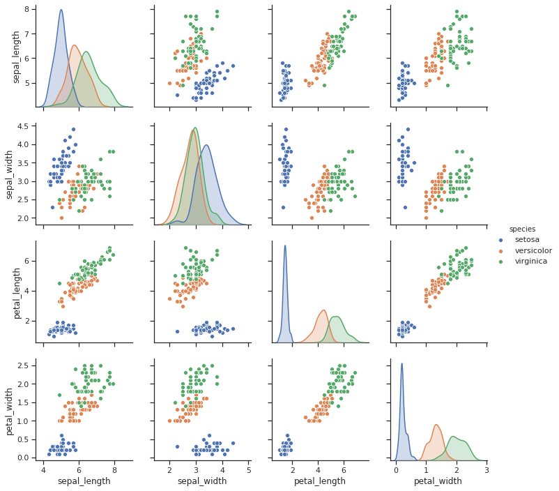

```python
sns.set(style="ticks")
df = sns.load_dataset("iris")
sns.pairplot(df, hue="species")
```

```python
iris.data.shape
```

```
(150, 4)
```

## Using `pandas` to manipulate the data

Pandas is great to manipulate data in a Microsoft Excel like way.

```python
# Create a dataframe with the four feature variables
df = pd.DataFrame(iris.data, columns=iris.feature_names)

# View the top 5 rows
df.head()
```

|  | sepal length (cm) | sepal width (cm) | petal length (cm) | petal width (cm) |
| --- | --- | --- | --- | --- |
| 0 | 5.1 | 3.5 | 1.4 | 0.2 |
| 1 | 4.9 | 3.0 | 1.4 | 0.2 |
| 2 | 4.7 | 3.2 | 1.3 | 0.2 |
| 3 | 4.6 | 3.1 | 1.5 | 0.2 |
| 4 | 5.0 | 3.6 | 1.4 | 0.2 |

```python
# Add a new column with the species names, this is what we are going to try to predict
df['species'] = pd.Categorical.from_codes(iris.target, iris.target_names)

# View the top 5 rows
df.head()
```

|  | sepal length (cm) | sepal width (cm) | petal length (cm) | petal width (cm) | species |
| --- | --- | --- | --- | --- | --- |
| 0 | 5.1 | 3.5 | 1.4 | 0.2 | setosa |
| 1 | 4.9 | 3.0 | 1.4 | 0.2 | setosa |
| 2 | 4.7 | 3.2 | 1.3 | 0.2 | setosa |
| 3 | 4.6 | 3.1 | 1.5 | 0.2 | setosa |
| 4 | 5.0 | 3.6 | 1.4 | 0.2 | setosa |

## Step 2: create training and test sets

Create a new column that for each row, generates a random number between 0 and 1, and if that value is less than or equal to .75, then sets the value of that cell as True and false otherwise. This is a quick and dirty way of randomly assigning some rows to be used as the training data and some as the test data.

```python
df['is_train'] = np.random.uniform(0, 1, len(df)) <= .75

# View the top 5 rows
df.head()
```

|  | sepal length (cm) | sepal width (cm) | petal length (cm) | petal width (cm) | species | is_train |
| --- | --- | --- | --- | --- | --- | --- |
| 0 | 5.1 | 3.5 | 1.4 | 0.2 | setosa | True |
| 1 | 4.9 | 3.0 | 1.4 | 0.2 | setosa | True |
| 2 | 4.7 | 3.2 | 1.3 | 0.2 | setosa | True |
| 3 | 4.6 | 3.1 | 1.5 | 0.2 | setosa | True |
| 4 | 5.0 | 3.6 | 1.4 | 0.2 | setosa | True |

```python
# Create two new dataframes, one with the training rows, one with the test rows
train, test = df[df['is_train']==True], df[df['is_train']==False]
```

```python
# Show the number of observations for the test and training dataframes
print('Number of observations in the training data:', len(train))
print('Number of observations in the test data:',len(test))
```

```
Number of observations in the training data: 118
Number of observations in the test data: 32
```

```python
# Create a list of the feature column's names
features = df.columns[:4]

# View features
features
```

```
Index(['sepal length (cm)', 'sepal width (cm)', 'petal length (cm)',
       'petal width (cm)'],
      dtype='object')
```

```python
# train['species'] contains the actual species names. Before we can use it,
# we need to convert each species name into a digit. So, in this case there
# are three species, which have been coded as 0, 1, or 2.
y_train = pd.factorize(train['species'])[0]
y_test = pd.factorize(test['species'])[0]
```

## Step 3: decision trees for the iris dataset

The method `tree.DecisionTreeClassifier()` from `scikit-learn` builds decision trees objects as follows:

```python
clf = tree.DecisionTreeClassifier()
clf = clf.fit(train[features], y_train)

# Using the whole dataset you may use directly:
#clf = clf.fit(iris.data, iris.target)
```

The `export_graphviz` exporter supports a variety of aesthetic options, including coloring nodes by their class (or value for regression) and using explicit variable and class names if desired. Jupyter notebooks also render these plots inline automatically:

```python
dot_data = tree.export_graphviz(clf, out_file=None,
                         feature_names=iris.feature_names,
                         class_names=iris.target_names,
                         filled=True, rounded=True,
                         special_characters=True)
graph = graphviz.Source(dot_data)
graph
```

[figure not shown]

We can also export the tree in Graphviz format and savethe resulting graph in an output file iris.pdf:

```python
dot_data = tree.export_graphviz(clf, out_file=None)
graph = graphviz.Source(dot_data)
graph.render("iris")
```

```
'iris.pdf'
```

After being fitted, **the model can then be used to predict the class of samples**:

```python
class_pred = clf.predict(iris.data[:1, :])
class_pred
```

```
array([0])
```

## Exercise 1

1. Train the decision tree on the iris dataset and explain how one should read blocks in `graphviz` representation of the tree.
2. Plot the regions of decision with the points of the training set superimposed.

*Indication: you may find the function `plt.contourf` useful.

```python
clf = tree.DecisionTreeClassifier()
clf = clf.fit(train[features], y_train)
```

Before moving on, it is worth noting that the dataset is very small (150 data points). We should expect this to induce a great variability in our results.

1.

The cell above creates a decision tree model and trains it on the train set.

The above representation of the tree works the following way:

- Each non-leaf node represents a linear boundary on one variable: feature < value
- Each node represents a point in the process, with additional informations: Gini coefficient, number of sample, chosen class
- Each leaf node represents the end of the classification
- The color of the node represents the classification: orange for setosa, green for versicolor, purple for veronica, and in-betweens when the node is not pure.

2.

The dataset is in 4 dimensions, it is therefore not trivial to visualize it. To do so, we want to project our dataset on a plane, plot the data and the boundary. We chose to project the data on the canonical base , i.e on two chosen features. We managed to do so using the numpy function `contourf` on a meshgrid of the two chosen features, concatenated with default values for the discarded features.

```python
def frontieres(clf, train, i1, i2, j1, j2):
    # j1, j2 are the features selected
    # i1, i2 are the features discarded
    X = train[[features[j1], features[j2]]].to_numpy()
    # We take the average value of each discarded value as default value
    mean1 = (train[features[i1]].min() + train[features[i1]].max())/2
    mean2 = (train[features[i2]].min() + train[features[i2]].max())/2

    h = .02
    # We create a grid of the values to display ...
    x1_min, x1_max = X[:, 0].min() - .5, X[:, 0].max() + .5
    x2_min, x2_max = X[:, 1].min() - .5, X[:, 1].max() + .5
    x11, x22 = np.meshgrid(np.arange(x1_min, x1_max, h),np.arange(x2_min, x2_max, h))
    # Create arrays of by-default values for the discarded features ...
    ln = product(x11.shape)
    t1, t2 = np.array([mean1]*ln).reshape(-1, 1), np.array([mean2]*ln).reshape(-1, 1)
    # And concatenate them at the right place.
    to_concat = [0, 0, 0, 0]
    to_concat[i1], to_concat[i2] = t1, t2
    to_concat[j1], to_concat[j2] = x11.ravel(), x22.ravel()
    A = np.column_stack(to_concat)
    # Prediction time
    Z = clf.predict(A)
    Z=Z.reshape(x11.shape)

    plt.contourf(x11, x22, Z, levels=[-0.1, 0.9, 1.9, 2.1], cmap=plt.cm.bwr, alpha=.8)
```

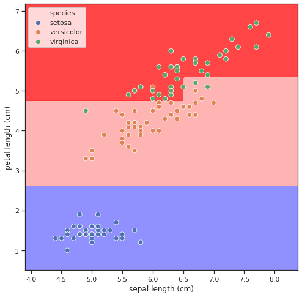

```python
plt.figure(figsize=(8, 8))
frontieres(clf, train, 1, 3, 0, 2)
sns.scatterplot(train[features[0]], train[features[2]], hue=train['species'], s=60)
```

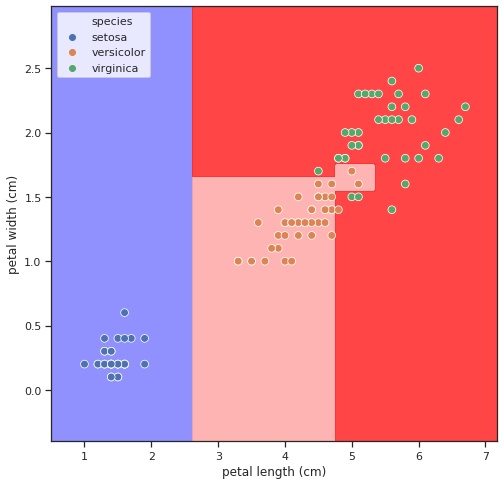

```python
plt.figure(figsize=(8, 8))
frontieres(clf, train, 0, 1, 2, 3)
sns.scatterplot(train[features[2]], train[features[3]], hue=train['species'], s=60)
```

We notice That the boundaries are correctly separating the visualised classes. We observe that the boundaries are linear and correspond to those of a decision tree, as expected.

Also, we can notice on the first plot that the decision boundaries are almost entirely horizontal in this case, i.e the sepal length is almost of no use compared to the petal length on the classification. We will prove later that the sepal features are less important than the petal features in the classification. On the second graph, we notice a slight tendency to overfitting with the small rectangle zone that only concerns two data points. We will see in the next questions whch parameters to tweak to avoid overfitting.

## Exercise 2

1. Build 2 different trees based on a sepal features (sepal lengths, sepal widths) vs petal features (petal lengths, petal widths) only: which features are the most discriminant?
2. Compare performances with those obtained using all features.
3. Try the same as above using the various splitting criterion available, Gini's index, classification error or cross-entropy. Comment on your results.

We define the function below to help us explore the impact of the different variables on the model

```python
def trainmodel(sentence, test_species=test['species'],
               train=train[features], test=test[features],
               y_train=y_train, y_test=y_test, **kwargs):
    # Create and fit the model
    clf = tree.DecisionTreeClassifier(**kwargs)
    clf = clf.fit(train, y_train)
    # Print the performance
    print(sentence.format(clf.score(test, y_test)))
    # Print the confusion matrix
    preds = clf.predict(test)
    preds_names = pd.Categorical.from_codes(preds, iris.target_names)
    confusiondf = pd.crosstab(test_species, preds, rownames=['Actual Species'], colnames=['Predicted Species'])
    display(HTML(confusiondf.to_html()))
```

1.

We can observe that the two petal features have a greater prediction potential than the two sepal features and get a 91% accuraccy compared to a 75% accuracy. This means that the petal features are the most important of the dataset

```python
trainmodel('sepal score: {:.2%}', train=train[features[0:2]], test=test[features[0:2]])
trainmodel('petal score: {:.2%}', train=train[features[2:4]], test=test[features[2:4]])
```

```
sepal score: 75.00%
```

| Predicted Species Actual Species | 0 | 1 | 2 |
| --- | --- | --- | --- |
| setosa | 11 | 2 | 0 |
| versicolor | 0 | 5 | 2 |
| virginica | 0 | 4 | 8 |

```
petal score: 90.62%
```

| Predicted Species Actual Species | 0 | 1 | 2 |
| --- | --- | --- | --- |
| setosa | 13 | 0 | 0 |
| versicolor | 0 | 4 | 3 |
| virginica | 0 | 0 | 12 |

2.

When using the entire dataset, we get a 94% accuracy, which is higher than the accuracy obtained when trained using only either the sepal or the petal features. This makes sense, since we are adding complementary information.

```python
trainmodel('total score: {:.2%}')
```

```
total score: 93.75%
```

| Predicted Species Actual Species | 0 | 1 | 2 |
| --- | --- | --- | --- |
| setosa | 13 | 0 | 0 |
| versicolor | 0 | 5 | 2 |
| virginica | 0 | 0 | 12 |

3.

We now want to compare the various criterions to measure the quality of a split. As visible below, the cross-entrpy criterion leads to a higher accuracy than the gini index in this case.

```python
trainmodel('with entropy: {:.2%}', criterion='entropy')
trainmodel('with gini:    {:.2%}', criterion='gini')
```

```
with entropy: 96.88%
```

| Predicted Species Actual Species | 0 | 1 | 2 |
| --- | --- | --- | --- |
| setosa | 13 | 0 | 0 |
| versicolor | 0 | 6 | 1 |
| virginica | 0 | 0 | 12 |

```
with gini:    93.75%
```

| Predicted Species Actual Species | 0 | 1 | 2 |
| --- | --- | --- | --- |
| setosa | 13 | 0 | 0 |
| versicolor | 0 | 5 | 2 |
| virginica | 0 | 0 | 12 |

We might also want to compare the strategies to chose the split at each node, i.e choosing the best split or a random split. We observe that in this run, the random strategy leads to a higher accuracy.

However, we can also notice that the parameters chosen in the 'best' setup are the same as those chosen in the 'gini' setup previously or the 'total dataset' setup two cells above. These two setups gave a 93.75% accuracy, while the 'best' setup here, with the exact same parameters, obtained a 90.62% accuracy. This is due to the randomness included in the decision tree, which can lead to different models with different performances.

```python
trainmodel('with best splitter: {:.2%}', splitter='best')
trainmodel('with rand splitter: {:.2%}', splitter='random')
```

```
with best splitter: 90.62%
```

| Predicted Species Actual Species | 0 | 1 | 2 |
| --- | --- | --- | --- |
| setosa | 13 | 0 | 0 |
| versicolor | 0 | 4 | 3 |
| virginica | 0 | 0 | 12 |

```
with rand splitter: 93.75%
```

| Predicted Species Actual Species | 0 | 1 | 2 |
| --- | --- | --- | --- |
| setosa | 13 | 0 | 0 |
| versicolor | 0 | 5 | 2 |
| virginica | 0 | 0 | 12 |

### Going further ahead (not mandatory)

Try the same approach adapted to another toy dataset from `scikit-learn` described at: http://scikit-learn.org/stable/datasets/index.html

Play with another dataset available at: http://archive.ics.uci.edu/ml/datasets.html

## Step 4: Random forests

Go to

http://scikit-learn.org/stable/modules/generated/sklearn.ensemble.RandomForestClassifier.html

for a documentation about the `RandomForestClassifier` provided by `scikit-learn`.

Since target values must be integers, we first need to transform labels into numbers as below.

```python
# Create a random forest Classifier. By convention, clf means 'Classifier'
rf = RandomForestClassifier(n_jobs=2, random_state=0, n_estimators=10)

# Train the Classifier to take the training features and learn how they relate
# to the training y (the species)
rf.fit(train[features], y_train)
```

```
RandomForestClassifier(bootstrap=True, class_weight=None, criterion='gini',
                       max_depth=None, max_features='auto', max_leaf_nodes=None,
                       min_impurity_decrease=0.0, min_impurity_split=None,
                       min_samples_leaf=1, min_samples_split=2,
                       min_weight_fraction_leaf=0.0, n_estimators=10, n_jobs=2,
                       oob_score=False, random_state=0, verbose=0,
                       warm_start=False)
```

**Make predictions** and create actual english names for the plants for each predicted plant class:

```python
preds = rf.predict(test[features])
preds_names = pd.Categorical.from_codes(preds, iris.target_names)
preds_names
```

```
[setosa, setosa, setosa, setosa, setosa, ..., virginica, virginica, virginica, virginica, virginica]
Length: 32
Categories (3, object): [setosa, versicolor, virginica]
```

### Create a confusion matrix

```python
# Create confusion matrix unsing pandas:
pd.crosstab(test['species'], preds, rownames=['Actual Species'], colnames=['Predicted Species'])
```

| Predicted Species Actual Species | 0 | 1 | 2 |
| --- | --- | --- | --- |
| setosa | 13 | 0 | 0 |
| versicolor | 0 | 5 | 2 |
| virginica | 0 | 0 | 12 |

## Feature selection using random forests byproducts

One of the interesting use cases for random forest is feature selection. One of the byproducts of trying lots of decision tree variations is that you can examine which variables are working best/worst in each tree.

When a certain tree uses one variable and another doesn't, you can compare the value lost or gained from the inclusion/exclusion of that variable. The good random forest implementations are going to do that for you, so all you need to do is know which method or variable to look at.

### View feature importance

While we don't get regression coefficients like with ordinary least squares (OLS), we do get a score telling us how important each feature was in classifying. This is one of the most powerful parts of random forests, because we can clearly see that petal width was more important in classification than sepal width.

```python
# View a list of the features and their importance scores
list(zip(train[features], rf.feature_importances_))
```

```
[('sepal length (cm)', 0.11185992930506346),
 ('sepal width (cm)', 0.016341813006098178),
 ('petal length (cm)', 0.36439533040889194),
 ('petal width (cm)', 0.5074029272799464)]
```

## Exercise 3

1. Comment on the feature importances with respect to your previous observations on decision trees above.
2. Extract and visualize 5 trees belonging to the random forest using the attribute `estimators_` of the trained random forest classifier. Compare them. *Note that you may code a loop on extracted trees.*
3. Study the influence of parameters like `max_depth`, `min_samples_leaf` and `min_samples_split`. Try to optimize them and explain your approach and choices.
4. How is estimated the prediction error of a random forest ? *Indication: have a look at parameter `oob_score`.* What are out-of-bag samples ?
5. What should you do when classes are not balanced in the dataset ? (that is when there are much more examples of one class than another)

1.

The feature importances obtained here comfort us in our previous conclusions. The cumulated feature importance of the petal features is about 87%, while the cumulated feature importance of the sepal features is of about 13%. This is coherent with the previous observation and allow us to state with a greater confidence that the petal features are more important than the sepal features in the classification.

2.

We can extract 5 of the 10 trees of the random forest with the following line:

```python
trees = rf.estimators_[:5]
```

```python
graphs = []
# N is the number of trees
N = 5
# steps is the number of times we want to loop on the N trees
steps=3
for i in range(N):
    dot_data = tree.export_graphviz(trees[i], out_file=None,
                             feature_names=iris.feature_names,
                             class_names=iris.target_names,
                             filled=True, rounded=True,
                             special_characters=True)
    # Creation of the list of the exported trees
    graphs.append(graphviz.Source(dot_data))
# Initialization of the display slot
display(graphs[0], display_id='1')
for i in range(steps*N):
    # 2 seconds pause for readability
    time.sleep(2)
    # Update of the displayed tree
    update_display(graphs[i%N], display_id='1')
```

[figure not shown]

```python
rf = RandomForestClassifier(n_jobs=2, random_state=0, n_estimators=10, max_depth=2)
rf.fit(train[features], y_train)
```

```
RandomForestClassifier(bootstrap=True, class_weight=None, criterion='gini',
                       max_depth=2, max_features='auto', max_leaf_nodes=None,
                       min_impurity_decrease=0.0, min_impurity_split=None,
                       min_samples_leaf=1, min_samples_split=2,
                       min_weight_fraction_leaf=0.0, n_estimators=10, n_jobs=2,
                       oob_score=False, random_state=0, verbose=0,
                       warm_start=False)
```

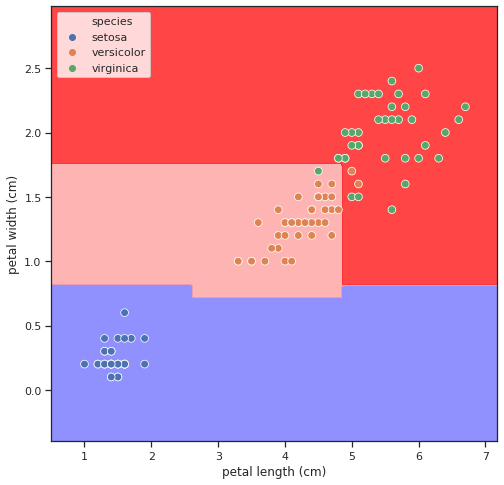

```python
plt.figure(figsize=(8, 8))
frontieres(rf, train, 0, 1, 2, 3)
sns.scatterplot(train[features[2]], train[features[3]], hue=train['species'], s=60)
```

This decision boundary is not necessarely more complex than the one obtained with a decision tree in the first exercice. We will see later which hyperparameters to tweak to improve the model.

3.

We want to compare the influence of various parameters on the final model. We will explore `max_depth`, `min_samples_leaf`, `min_samples_split`, `n_estimators` and `max_leaf_nodes`. To facilitate this exploration, we created the function below that trains `N=50` random forests to get an average score, display one random tree of the forest to visualize the effect of the parameters, and get the average execution time of a random forest.

```python
def trainRF(sentence, N=20, test_species=test['species'],
            train=train[features], test=test[features],
            y_train=y_train, y_test=y_test, **kwargs):
    start = time.time()
    avg_score = 0
    # training of N random forests
    for n in range(N):
        clf = RandomForestClassifier(**kwargs)
        clf = clf.fit(train, y_train)
        # Update of the score
        avg_score += 1/N * clf.score(test, y_test)
    end = time.time()
    # Print the average score
    print(sentence.format(avg_score))
    dot_data = tree.export_graphviz(clf.estimators_[0], out_file=None,
                         feature_names=iris.feature_names,
                         class_names=iris.target_names,
                         filled=True, rounded=True,
                         special_characters=True)
    # Display one tree
    print('one tree:')
    display(graphviz.Source(dot_data))
    # print the average execution time
    print('average time: {:.0f} ms'.format((end-start)/N*1e3))
```

```python
trainRF('default parameters: {:.2%}', N=50, n_estimators=10)
```

```
default parameters: 94.44%
one tree:
```

[figure not shown]

```
average time: 70 ms
```

With the default parameters, we obtain a 94.44% accuracy and a depth of 5 for this tree. We can notice that some of the leaf nodes contains only 1 sample, which is a sign of overfitting. This effect is partially counterweighted by the number of estimators that majes the prediciton more robust.

```python
trainRF('max_depth=2: {:.2%}', N=50, n_estimators=10,
        max_depth=2)
```

```
max_depth=2: 92.56%
one tree:
```

[figure not shown]

```
average time: 60 ms
```

As expected, the max_depth parameters controls the maximum depth of every tree of the forest. Limiting the tree depth leads to a control of the overfitting, and eventually to underfitting if the max_depth is too small to build more complex predictions.

```python
trainRF('min_samples_split=20: {:.2%}', N=50, n_estimators=10,
        min_samples_split=20)
```

```
min_samples_split=20: 94.37%
one tree:
```

[figure not shown]

```
average time: 46 ms
```

```python
trainRF('min_samples_split=20%: {:.2%}', N=50, n_estimators=10,
        min_samples_split=0.2)
```

```
min_samples_split=20%: 92.87%
one tree:
```

[figure not shown]

```
average time: 50 ms
```

The min_samples_split feature controls the number of sample below which a node is not allowed to create an other split. This still allows node with less than min_samples_split samples to exist, but thay won't beable to split themselves. The bigger this parameter is, the more it will prevent overfitting but will tend to underfit naturally.

```python
trainRF('min_samples_leaf=5: {:.2%}', N=50, n_estimators=10,
        min_samples_leaf=5)
```

```
min_samples_leaf=5: 92.62%
one tree:
```

[figure not shown]

```
average time: 60 ms
```

```python
trainRF('min_samples_leaf=10%: {:.2%}', N=50, n_estimators=10,
        min_samples_leaf=0.1)
```

```
min_samples_leaf=10%: 92.75%
one tree:
```

[figure not shown]

```
average time: 60 ms
```

The min_samples_leaf parameter controls the minimum number of samples accepted for a node. The higher this parameter, the lesser the tree depth and the lesser the overfitting will be.

```python
trainRF('n_estimators=100: {:.2%}', N=50, n_estimators=100)
```

```
n_estimators=100: 93.81%
one tree:
```

[figure not shown]

```
average time: 388 ms
```

As we can see here, the higher the number of estimators, the longer the training and the evaluation will take. This is what we can expect, since training 10 times more models should take 10 times longer. Also, adding more estiamtors is reinforcing the robustness of the model and prevents overfitting as well.

```python
trainRF('max_leaf_nodes=4: {:.2%}', N=50, n_estimators=10,
        max_leaf_nodes=4)
```

```
max_leaf_nodes=4: 93.56%
one tree:
```

[figure not shown]

```
average time: 55 ms
```

finally, the max_leaf_nodes prameter controls the maximum number of leaves nodes in each tree. If reduced too much, the trees won't be able to make enough splits to get correct performances, and the forest will underfit.

Above all the parameters above, many have an impact on the tendency of the model to overfit, but on different ways: tree depth, number of leaves, number of sample per leave, etc. A good model should combinate the above parameters to find the optimal spot. To do so, we chose to use a gridsearch that will explore exhaustively combinations of the parameters. We chose revelant values for each parameters using our understanding of their effects, and let the gridsearch give us the combination leading to the best performances.

```python
parameters = {'n_estimators': [10, 50, 100],
              'max_depth': [None, 2, 3, 5],
              'min_samples_split': [2, 4, 8, 16],
              'min_samples_leaf': [1, 2, 4, 8]}

rf = RandomForestClassifier()
clf2 = GridSearchCV(rf, parameters, cv=3)
clf2.fit(train[features], y_train)
```

```
GridSearchCV(cv=3, error_score='raise-deprecating',
             estimator=RandomForestClassifier(bootstrap=True, class_weight=None,
                                              criterion='gini', max_depth=None,
                                              max_features='auto',
                                              max_leaf_nodes=None,
                                              min_impurity_decrease=0.0,
                                              min_impurity_split=None,
                                              min_samples_leaf=1,
                                              min_samples_split=2,
                                              min_weight_fraction_leaf=0.0,
                                              n_estimators='warn', n_jobs=None,
                                              oob_score=False,
                                              random_state=None, verbose=0,
                                              warm_start=False),
             iid='warn', n_jobs=None,
             param_grid={'max_depth': [None, 2, 3, 5],
                         'min_samples_leaf': [1, 2, 4, 8],
                         'min_samples_split': [2, 4, 8, 16],
                         'n_estimators': [10, 50, 100]},
             pre_dispatch='2*n_jobs', refit=True, return_train_score=False,
             scoring=None, verbose=0)
```

```python
clf2.best_estimator_.score(test[features], y_test)
```

```
0.96875
```

We obtain here a better accuracy than before. The parameters are shown below. We can notice that the max_depth and min_samples_leaf parameters are those by default, and are not preventing overfitting (no maximum tree depth and a minimum of 1 sample per leaf). The two others, however, are leading the model toward a lesser overfitting with more estimators (50) and a minimum of 8 samples per node to operate a split.

```python
{k: v for k, v in clf2.best_estimator_.get_params().items() if k in parameters.keys()}
```

```
{'max_depth': None,
 'min_samples_leaf': 1,
 'min_samples_split': 8,
 'n_estimators': 50}
```

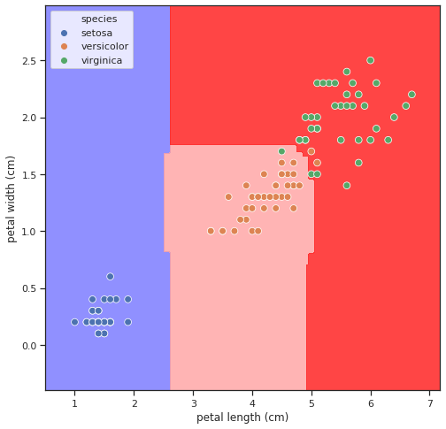

```python
plt.figure(figsize=(8, 8))
frontieres(clf2, train, 0, 1, 2, 3)
sns.scatterplot(train[features[2]], train[features[3]], hue=train['species'], s=60)
```

This decision boundary is more complex and seems more robust than the ones obtained in exercices 1 and 3. Only 3 points are misclassified, and we can see that the model does not overfit anymore.

4.

Random Forests are Bagging models: they consists of a bootstrapping of the data (sampling the dataset according to its own distribution) for each estimator (here, decision trees) and aggregating the results (on a majority vote).

The bootstraping step implies that for every decision tree, some data points are not included in its training set and could be reused for estimating the performances of the model. The data points excluded from the training set are called out-of-sample points.

The out-of-bag score is computed as following: For each point which is not included in at least one estimator, find all models that are not including it in its training set, evaluate it, and make a majority vote beetween these estimators. Comparing all these results to the ground truths gives the OOB score.

5.

The parameters `class_weight` allows to modify the weight given to different classes, and balance unbalanced dataset. The best option when we don't have enough information on the data is `clas_weight = balanced`, which weight each class inversely proportionally their apparition frequency in the dataset: $w_j=\frac{N}{k*n_j}$ with $w_j$ the weigth of the class j, $N$ the number of data points, $n_j$ the number of data points in the class j and $k$ the number of classes.

## Step 5: a small example of regression using random forests

Random forest is capable of learning without carefully crafted data transformations. Take the the $f(x) = \sin(x)$ function for example.

Create some fake data and add a little noise.

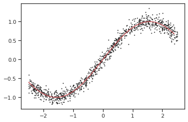

```python
x = np.random.uniform(-2.5, 2.5, 1000)
y = np.sin(x) + np.random.normal(0, .1, 1000)

x_test = np.random.uniform(-2.5, 2.5, 997) #997 is prime so the elements will be differents from the train set
y_test = np.sin(x_test) + np.random.normal(0, .1, 997)

plt.plot(x,y,'ko',markersize=1,label='data')
plt.plot(np.arange(-2.5,2.5,0.1),np.sin(np.arange(-2.5,2.5,0.1)),'r-',label='ref')
plt.show()
```

If we try and build a basic linear model to predict y using x we end up with a straight line that sort of bisects the sin(x) function. Whereas if we use a random forest, it does a much better job of approximating the sin(x) curve and we get something that looks much more like the true function.

Based on this example, we will illustrate how the random forest isn't bound by linear constraints.

## Exercise 4

1. Apply random forests on this dataset for regression and compare performances with ordinary least squares regression. *Note that ordinay least square regression is available thanks to: from sklearn.linear_model import LinearRegression*
2. Comment on your results.

We created above a test and a train dataset of 1000 (resp. 997) data points. We chose the number of data points in the test set to be prime with 1000, so that elements of the train set are not included in the train set.

```python
x = x.reshape(-1, 1)
x_test = x_test.reshape(-1, 1)
```

We implement the function below to return the r2 score and the mean squared error on the test set of a given model.

```python
def compare_model(name, model, x=x, y=y,
                  x_test=x_test, y_test=y_test):
    model.fit(x, y)
    pred = model.predict(x_test)
    print(name)
    print('r2 score: {:.3f}'.format(r2_score(pred, y_test)))
    print('mean squared error: {:.3f}\n'.format(mean_squared_error(pred, y_test)))
    return pred
```

```python
pred_rfr = compare_model('Random Forest', RandomForestRegressor(n_estimators=30, max_depth=4))
pred_lr = compare_model('Linear Regression', LinearRegression())
```

```
Random Forest
r2 score: 0.981
mean squared error: 0.011

Linear Regression
r2 score: 0.820
mean squared error: 0.086
```

The performances obtained demonstrates that the linear regression performs poorly on this non-liner real function, while the random forest regressor obtains satisfying performances. The graph below allows visualize the predictions of each model:

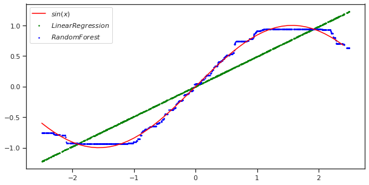

```python
plt.figure(figsize=(10, 5))
plt.scatter(x_test, pred_lr, s=2, c='green', label='$Linear Regression$')
plt.scatter(x_test, pred_rfr, s=2, c='blue', label='$Random Forest$')
plt.plot(np.arange(-2.5,2.5,0.1),np.sin(np.arange(-2.5,2.5,0.1)),'r-',label='$sin(x)$', c='red')
plt.legend()
plt.show()
```

This higlights the linear behaviour of the linear regression, and the non-linear behaviour of the random forest. We find here the piecewise constant profile of the random forest regressor that we were expecting, as the aggregation of several decision trees.

## Documentation

### Decision trees

http://scikit-learn.org/stable/modules/tree.html

### Random forests

http://scikit-learn.org/stable/modules/generated/sklearn.ensemble.RandomForestClassifier.html

### Plot decision surface : using `plt.contourf`

http://scikit-learn.org/stable/auto_examples/tree/plot_iris.html#sphx-glr-auto-examples-tree-plot-iris-py

## Pruning trees: not available in scikit-learn.

Since post-pruning of tree is not implemented in scikit-learn, you may think of coding your own pruning function. For instance, taking into account the numer of samples per leaf as proposed below:

```python
# Pruning function (useful ?)
def prune(decisiontree, min_samples_leaf = 1):
    if decisiontree.min_samples_leaf >= min_samples_leaf:
        raise Exception('Tree already more pruned')
    else:
        decisiontree.min_samples_leaf = min_samples_leaf
        tree = decisiontree.tree_
        for i in range(tree.node_count):
            n_samples = tree.n_node_samples[i]
            if n_samples <= min_samples_leaf:
                tree.children_left[i]=-1
                tree.children_right[i]=-1
```